# Lab: Conversion rate

Jimmy Azar

## Introduction

In this lab, we will analyze customer conversion rate as a KPI in marketing.

The dataset is gathered from a bank marketing campaign based on phone calls to bank clients in the aim of subscribing clients to a term deposit. Conversion in this context is based on whether the client did subscribe (“yes”) or not (“no”) to a term deposit.

## Data exploration

The data is provided in the file “conversion.txt”. Read the file using `read.table()` and inspect the data. The following is a descriptive summary of the attributes and target variable.

```
Input variables:
# bank client data:
1 - age (numeric)
2 - job : type of job
3 - marital : marital status
4 - education
5 - default: has credit in default?
6 - housing: has housing loan?
7 - loan: has personal loan?
# related with the last contact of the current campaign:
8 - contact: contact communication type
9 - month: last contact month of year
10 - day_of_week: last contact day of the week
11 - duration: last contact duration, in seconds. Important note: this attribute highly affects the output target (e.g., if duration=0 then y='no'). Thus, this input should only be included for benchmark purposes and should be discarded if the intention is to have a realistic predictive model.
# other attributes:
12 - campaign: number of contacts performed during this campaign and for this client
13 - pdays: number of days that passed by after the client was last contacted from a previous campaign (999 means client was not previously contacted)
14 - previous: number of contacts performed before this campaign and for this client
15 - poutcome: outcome of the previous marketing campaign
# social and economic context attributes
16 - emp_var_rate: employment variation rate - quarterly indicator
17 - cons_price_idx: consumer price index - monthly indicator
18 - cons_conf_idx: consumer confidence index - monthly indicator
19 - euribor3m: euribor 3 month rate - daily indicator
20 - nr.employed: number of employees - quarterly indicator
#Output variable (desired target):
21 - y - has the client subscribed a term deposit?
```

## Conversion rates

Transform the conversion variable into a binary numeric variable where 1 represents “yes” and 0 represents “no” (hint: `as.numeric()`). Compute the total number of conversions out of all responses, and indicate the overall conversion rate as a percentage.

### By number of contacts

We will analyze conversion as a function of the number of contacts conducted by the bank to a client. Create a data frame consisting of four columns: the number of contacts (hint: `$campaign`), the count for each number of contacts in the data (hint: `aggregate()`; `length()`), the total number of conversions (hint: `aggregate()`; `sum()`), and the conversion rate (as percentage) derived from the previous two values. Finally, make sure you assign meaningful names to the columns. Show the first few rows using `head()`, and plot the conversion rates as a function of the number of contacts for the first 10 elements (i.e. number of contacts ranging from 1 to 10).

```
plot(x = ... , y = ..., type="b", lwd = 3, xlab="number of contacts", ylab="conversion rate (%)")
```

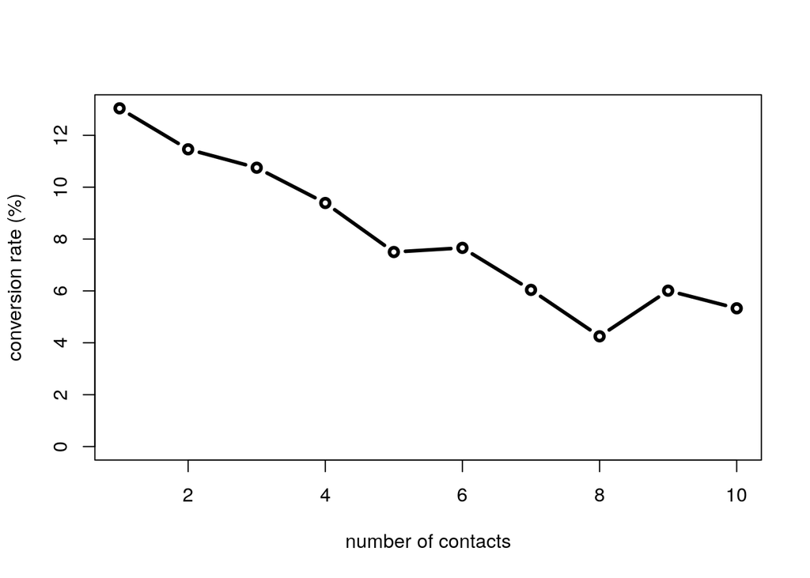

### By age

Let’s now study the conversion rate as a function of age. Create a data frame with four columns consisting of age, count of each age, the total number of conversions for each age, and conversion rate as a percentage. Print the first few rows of the data frame, and generate a plot showing the percentage conversion rate as a function of age. What can you conclude from the plot.

### By age group

You may have noticed that conversion rate values are not very stable for high age. This is due to the fact that the sample size (number of clients) becomes small for high ages (you may check how the count changes with age in your previous data frame). Therefore, to reduce noise, we will set up age groups and create a bar plot showing the conversion rate for each group. Set up a variable for age group, and for each client whose age is in (20-30], assign the character “(20-30]”, and in a similar way assign the following age groups “(30-40]”, “(40-50]”, “(50-60]”, “(60-70]”, and “70+”.

As before, create a data frame with four columns consisting of age group, count of each age group, the total number of conversions for each age group, and conversion rate as a percentage. Print the first few rows of the data frame, and generate a bar plot showing the percentage conversion rate as a function of age group.

```
barplot(..., names.arg = ..., beside = TRUE, xlab="age", ylab="conversion rate (%)")
```

### By marital status

Create a data frame with four columns consisting of marital status, count of each marital status in the dataset, the total number of conversions for each status, and conversion rate as a percentage. Print the first few rows of the data frame, and generate a pie chart showing the percentage conversion rate as a function of marital status. What can you conclude from the plot.

```
pie(x = ..., labels = ..., col = rainbow(length(...)), main = "conversion rate by marital status")
```

### By education

Repeat the previous exercise but for level of education. Print the first few rows of the resulting data frame, and generate a pie chart showing the percentage conversion rate as a function of education. What can you conclude from the plot.

```
##             education count total_conversions conv_rate
## 1            basic.4y  4176               428     10.25
## 2            basic.6y  2292               188      8.20
## 3            basic.9y  6045               473      7.82
## 4         high.school  9515              1031     10.84
## 5          illiterate    18                 4     22.22
## 6 professional.course  5243               595     11.35
## 7   university.degree 12168              1670     13.72
## 8             unknown  1731               251     14.50
```

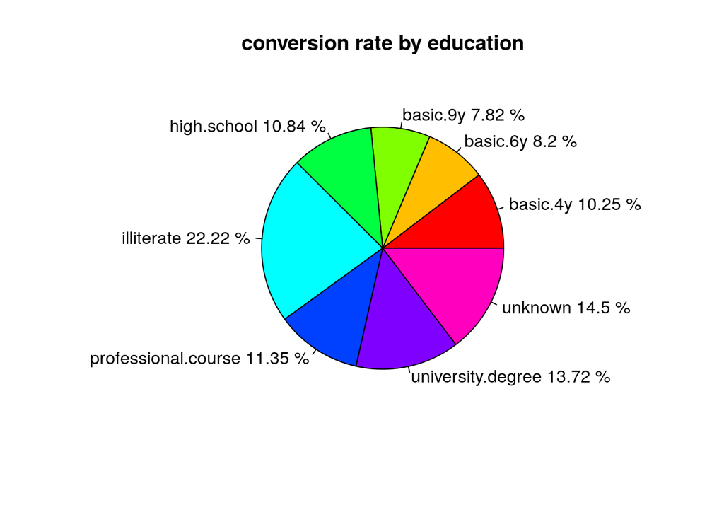

### By job

Repeat the previous exercise by analyzing conversion rate as a function of job type. Print the first few rows of the resulting data frame, and generate a horizontal bar plot showing the percentage conversion rate as a function of job type. What can you conclude from the plot.

```
barplot(..., names.arg = ...,
        beside = TRUE, horiz = TRUE,
        cex.names = 0.7, las=2,
        xlab="conversion rate (%)", ylab="")
```

## Duration of last contact

Compute the duration (in hours) of the last contact with the bank for each client (hint: `$duration`). Note that the duration in the dataset is originally provided in seconds (as mentioned in the attribute descriptions above). Create two horizontal box plots in the same figure summarizing the spread of duration values for the case of conversions and non-conversions (hint: use formula statement within `boxplot()`).

```
boxplot(..., data = ...,
        main="last contact duration",
        ylab="conversion status",
        xlab="duration (in hours)",
        horizontal=TRUE,
        col=c("red","blue"))
```

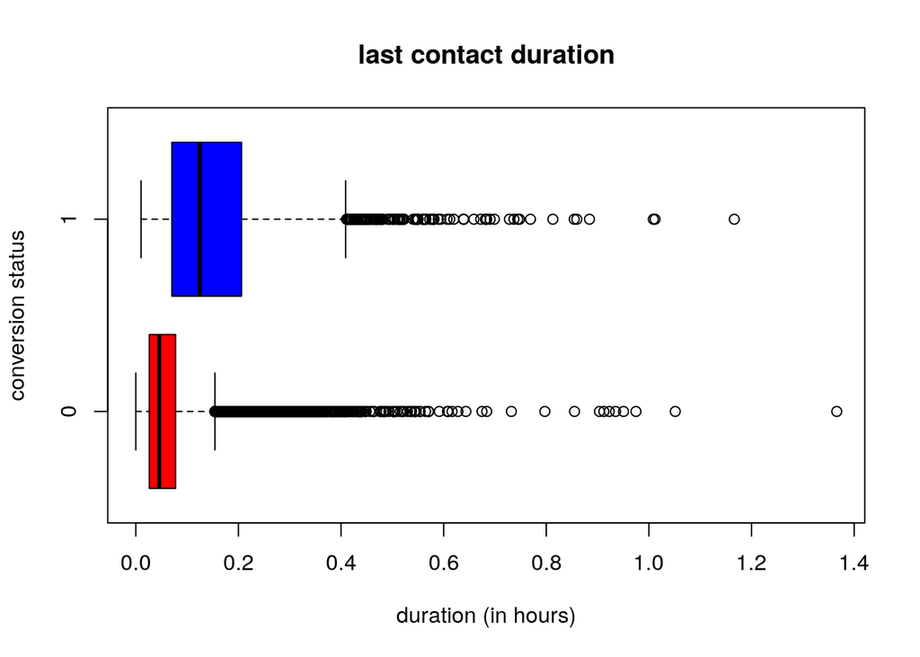

## Logistic regression

Construct a logistic regression model for predicting conversion (0 or 1) from the attributes: “age”, “campaign” (number of contacts), “previous”, “marital”, “job”, and “housing”. Inspect the model using `summary()`. Which attributes are positively/negatively correlated with conversion.

```
model <- glm(formula =  conversion ~ age + campaign + previous +
             factor(marital) + factor(job) + factor(housing),
             data = df, family = binomial)
```